# US Flights of 2008

## by (Ahmed Almalki)

## Investigation Overview

Exploring US flights of 2008 and answering on:-

- what are the best airports/states in terms of delayed and cancelled flighes?
- what are the best airlines in terms of delayed and cancelled flighes?
- what are the best flights in terms of delayed and cancelled flighes?

## Dataset Overview

The dataset reports flights in the United States, including carriers, arrival and departure delays from 1987 to 2008. Actually, the report treated flight details of 2008 which is (7,009,728) observations.

## Recommended Locations in Terms of Delayed & Cancelled Flights

- The rate of cancelled flights is high in `Pierre Regional Airport`, `Pueblo Memorial Airport` & `Tupelo Regional Airport`.
- The rate of delayed departures is distributed in whole US.
- The rate of delayed arrivals is high in `Pueblo Memorial Airport`.

### Distribution of Cancelled Flights

[figure not shown]

### Distribution of Delay (Departure)

[figure not shown]

### Distribution of Delay (Arr)

[figure not shown]

## Recommended Airlines to Avoice Delay & Cancellation

Airlines with minimum rate of delayed & cancelled flightes:-  
`Southwest Airlines` & `US Airways`, `Aloha Airlines`, `Hawaiian Airlines` & `Alaska Airlines`.

Airlines with maximum rate of delayed & cancelled flightes:-  
`American Airlines`, `American Eagle Airlines`, `United Air Lines`, `Expressjet Airlines`, `Mesa Airlines` & `Comair`.

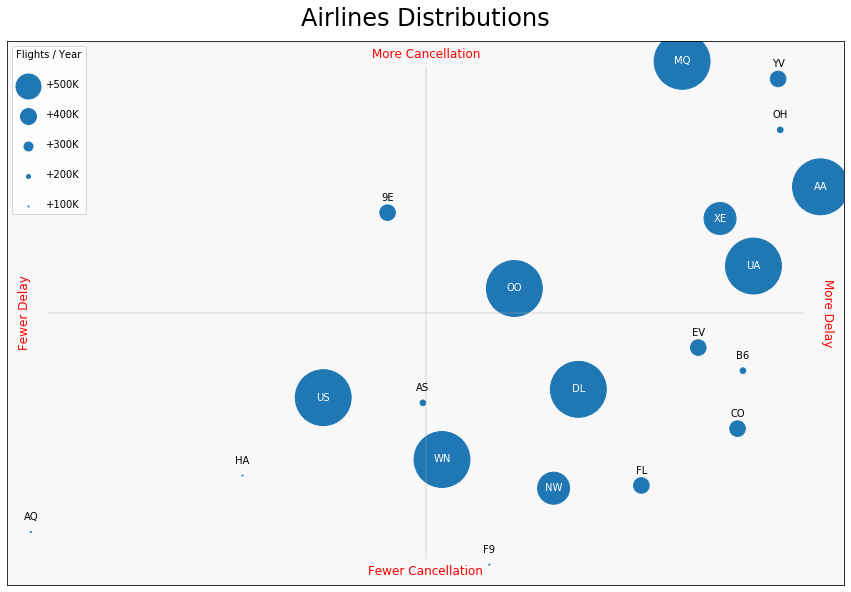

```python
plt.figure(figsize=[15,10])

for size in np.arange(5,0,-1):
    plt.scatter([], [], c='C0', s=size**4, label='+'+ str(size*100) + 'K')
plt.legend(scatterpoints=1,
           labelspacing=2,
           frameon=True,
           title='Flights / Year',
           mode=2
          )

ax = plt.subplot()
ax.scatter(airlines.ArrDelay, airlines.Cancelled, s=airlines.Size**5, c='C0')

x_max = max(airlines.ArrDelay)
x_min = min(airlines.ArrDelay)

y_max = max(airlines.Cancelled)
y_min = min(airlines.Cancelled)

x_len =  x_max - x_min
y_len =  y_max - y_min

x = x_len*.03
y = y_len*.04

ax.set_xlim(x_min-x, x_max+x)
ax.set_ylim(y_min-y, y_max+y)

ax.axhline(y=y_max-(y_len/2), xmin=.05, xmax=.95, color='darkgray', alpha=.3)
ax.axvline(x=x_max-(x_len/2), ymin=.05, ymax=.95, color='darkgray', alpha=.3)

ax.text(x_min,y_max-(y_len/2),'Fewer Delay', rotation=90, fontsize=12, color='r', ha='right', va='center')
ax.text(x_max,y_max-(y_len/2),'More Delay', rotation=-90, fontsize=12, color='r', ha='left', va='center')

ax.text(x_max-(x_len/2),y_min,'Fewer Cancellation', rotation=0, fontsize=12, color='r', ha='center', va='top')
ax.text(x_max-(x_len/2),y_max,'More Cancellation', rotation=0, fontsize=12, color='r', ha='center', va='bottom')
ax.get_xaxis().set_visible(False)
ax.get_yaxis().set_visible(False)

ax.set_facecolor('#f8f8f8')
ax.set_title('Airlines Distributions', fontsize=24, pad=15)


for i, name in enumerate(airlines.UniqueCarrier):
    if(airlines.Size[i]>3):
        ax.text(airlines.ArrDelay[i], airlines.Cancelled[i], name, ha='center', va='center', color='w')
    else:
        ax.text(airlines.ArrDelay[i], airlines.Cancelled[i]+.001, name, ha='center', va='center', color='k')
```

## Recommended Flights Time to Avoice Delay & Cancellation

`AM flights` are cancelled more than `PM flights`, while `PM flights` are more delayed than `AM flights`.

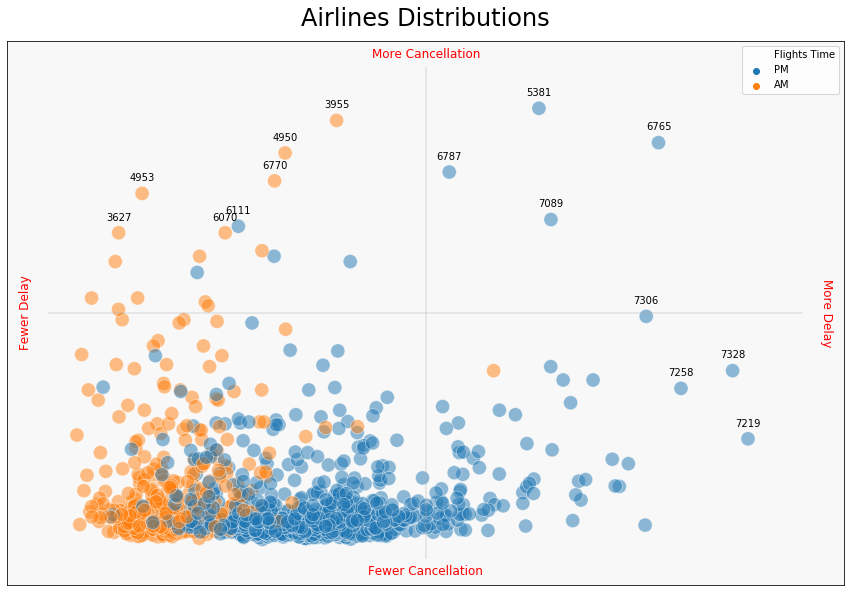

```python
plt.figure(figsize=[15,10])

ax = plt.subplot()

ax = sb.scatterplot(flights_filtered.DepDelay,
           flights_filtered.Cancelled,
           hue=flights_filtered.DepTimePM, s=200, alpha=.5)

legend = ax.legend()
legend.texts[0].set_text("Flights Time")

# x_max = max(flights_filtered.DepDelay)
x_max = 50
x_min = min(flights_filtered.DepDelay)

# y_max = max(flights_filtered.Cancelled)
y_max = .03
y_min = min(flights_filtered.Cancelled)

x_len =  x_max - x_min
y_len =  y_max - y_min

x = x_len*.1
y = y_len*.1

ax.set_xlim(x_min-x, x_max+x)
ax.set_ylim(y_min-y, y_max+y)

ax.axhline(y=y_max-(y_len/2), xmin=.05, xmax=.95, color='darkgray', alpha=.3)
ax.axvline(x=x_max-(x_len/2), ymin=.05, ymax=.95, color='darkgray', alpha=.3)

ax.text(x_min-3.5,y_max-(y_len/2),'Fewer Delay', rotation=90, fontsize=12, color='r', ha='right', va='center')
ax.text(x_max+3.5,y_max-(y_len/2),'More Delay', rotation=-90, fontsize=12, color='r', ha='left', va='center')

ax.text(x_max-(x_len/2),y_min-.0017,'Fewer Cancellation', rotation=0, fontsize=12, color='r', ha='center', va='top')
ax.text(x_max-(x_len/2),y_max+.0017,'More Cancellation', rotation=0, fontsize=12, color='r', ha='center', va='bottom')
ax.get_xaxis().set_visible(False)
ax.get_yaxis().set_visible(False)

ax.set_facecolor('#f8f8f8')
ax.set_title('Airlines Distributions', fontsize=24, pad=15)


for i, name in enumerate(flights_filtered.FlightNum):
    if((flights_filtered.DepDelay[i]>40) & (flights_filtered.DepDelay[i]<x_max)):
        ax.text(flights_filtered.DepDelay[i],
                flights_filtered.Cancelled[i]+.001,
                name, ha='center', va='center', color='k'
               )
    elif((flights_filtered.Cancelled[i]>0.02) & (flights_filtered.Cancelled[i]<y_max)):
        ax.text(flights_filtered.DepDelay[i],
                flights_filtered.Cancelled[i]+.001,
                name, ha='center', va='center', color='k'
               )
```

```python
# from subprocess import call
# call(['python', '-m', 'nbconvert', 'wrangle_report.ipynb'])

!jupyter nbconvert slide_deck.ipynb --to slides --post serve --template output_toggle
```